# Analysis

## Motivation

Most of our teammates are international students from China and Korea. We found an article that the number of international students in the US unprecedentedly decreased during 2019 to 2020. The widespread travel restrictions tend to lead to a sharp decline in enrollments of new students outside of the US. We wanted to check what would affect the international students to choose certain institutions in the US. One of our teammates, Yawei suggested that the top three considerations were: safety, ranking of the university in my field, and the “dynamics” of the campus. The percentage of the international student body would fall under the third category. However, while there has been quite convenient data on the first two categories, the judgment of the third was more based on gut or anecdotes. The rankings on US News, for example, are a weighted composite score of many aspects, but we were not sure whether the international student body is one of the criteria (probably not, but I believe there is correlation there). Therefore, we considered that we could explore more about this potential correlation (x=% of international students, y=rankings) while trying to add in other interesting and relevant information, such as the nationalities of international students, crime rate of the city, etc

The “main” research question is to explore the relationship between percentage of international student population (x-axis) and the ranking of US universities (y-axis). We can then add more interesting complexities/layers to the basic graph through “group_by”, “color”, “fill”, “facet” and different “geoms_plots” using variables such as nationalities, number of (top xx) universities in the city, crime rates of the city, location of the university (on a US map), and ranking type (e.g., undergraduate, graduate cs, graduate education, graduate business, graduate law). We also wanted to answer the questions below: How has the number of international students in the US changed over time? (x= school years, y= international students’ population) New enrollment percentage of international students (x= school years, y= international students’ population % change) How do new enrollment trends vary by academic level? Breakdown of international students by the US region they live (2021 vs 2016)

## Breadth and Depth of DA

Our group’s target variables are the international student population (ISPo) and proportion (ISPr) in US colleges, and we aim to identify the potential factors that correlate to and predict ISPo and ISPr.

## Early Data Analysis

The main limitation is that we naively selected one predictor variable (Alumni and Publications) and did not assess the correlations.

## Current Data Analysis

```
## [1] international_students_opendoors enrollment_top120enrollment
## [3] city_population                  international_students_qs
## [5] international_students_natlib    city_population_density
## 22 Levels: score_qs pub_arwu n_s_arwu alumni_arwu hi_ci_arwu ... faculty_count_qs
## [1] city_population_density faculty_count_qs
## 22 Levels: score_qs pub_arwu n_s_arwu alumni_arwu hi_ci_arwu ... faculty_count_qs
```

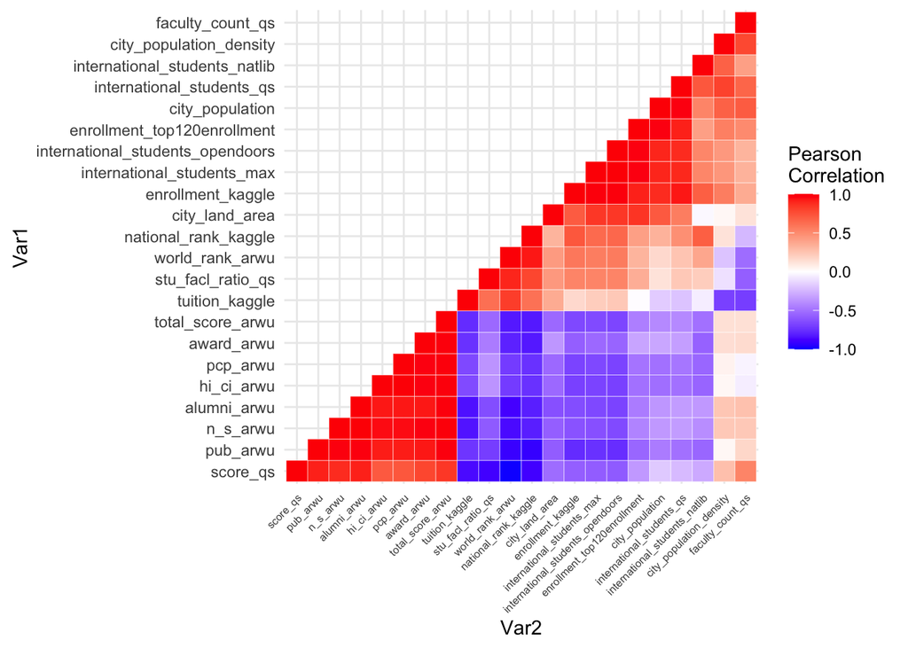

The correlation matrix helps find high positive or negative correlations, and we select numerical features that have an absolute value of correlation coefficient greater than 0.4 with respect to ISPo and ISPr. For ISPo, the relevant numerical features are international_students_opendoors, enrollment_top120enrollment, city_population, international_students_qs, international_students_natlib, and city_population_density. For ISPr, the relevant numerical features are city_population_density and faculty_count_qs.

## Feature Extraction (In Progress)

We have found that computing the correlation between categorical and continuous variables is a bit tedious; since the categorical variables are not binary, we cannot apply point-biserial correlation. We have identified a few potential methods to work around such as numerical encoding from categorical to numerical, logistic regression, and the x2y metric. We are currently using logistic regression to compare the pairwise correlations. We understand this approach assumes a linear relationship between the predictor and the logit of the outcome.

The 15 categorical variables are “university”, “city”, “state”, “selectivity”, “world_rank_cat_arwu”, “world_rank_qs”, “national_rank_arwu”, “type1_all”, “type2_carnegie”, “type3_natlib”, “type4_carnegie”, “enrprofile2021_carnegie”, “locale_carnegie”, “size_qs”, and “research_output_qs”.

We remove the university variable because it is unique for all observations. Similarly, because we have limited data in general for cities and states, they are not reliable predictors and introduce unnecessary noise. Thus, we are in the process of numerically encoding the variables: selectivity, size_qs, research_output_qs, type1_all, type2_carnegie, and locale_carnegie.

The following modeling section exclusively addresses our current data analysis.

## Modeling

Linear Regression has a mean absolute error of *0.02577159* and Logistic Regression has a mean absolute error of *0.02558677*

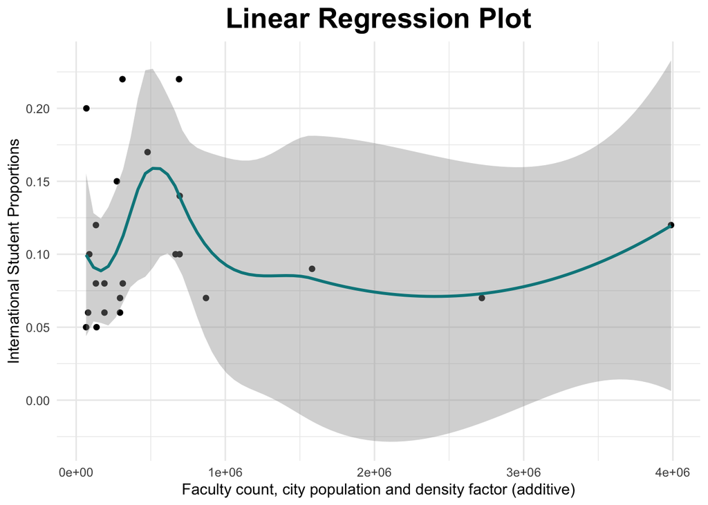

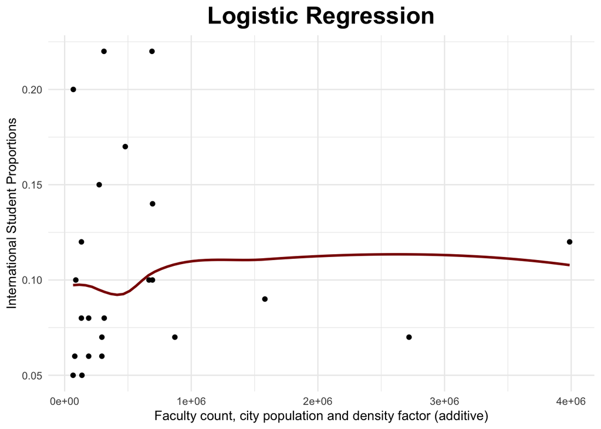

# Flaws and limitations

### Limitation 1.

One of the main limitations is that for our models we don’t introduce any categorical variables. We address this in the Feature Extraction (In Progress) section. Alternatively, we are interested in leveraging the regsubsets subroutine in the leaps library to compare modeling with different variables, which provides performance criteria such as Adjusted R2 score, Bayesian Information Criterion, Mallow’s Cp.

### Limitation 2.

On the other hand, due to the sparsity of the data, if we include certain predictors, the overall data for training and testing may shrink to 10 observations, which leads to not unreliable modeling and predictions.

## Rubric: On this page

**NOTE**: Your Data Analysis can be broken up into multiple pages if that helps with your organization.